# Market Segmentation

First, load the data.

```r
df = read.csv("social_marketing.csv")
```

View a sample of the data:

```r
head(df)
```

```
##           X chatter current_events travel photo_sharing uncategorized
## 1 hmjoe4g3k       2              0      2             2             2
## 2 clk1m5w8s       3              3      2             1             1
## 3 jcsovtak3       6              3      4             3             1
## 4 3oeb4hiln       1              5      2             2             0
## 5 fd75x1vgk       5              2      0             6             1
## 6 h6nvj91yp       6              4      2             7             0
##   tv_film sports_fandom politics food family home_and_garden music news
## 1       1             1        0    4      1               2     0    0
## 2       1             4        1    2      2               1     0    0
## 3       5             0        2    1      1               1     1    1
## 4       1             0        1    0      1               0     0    0
## 5       0             0        2    0      1               0     0    0
## 6       1             1        0    2      1               1     1    0
##   online_gaming shopping health_nutrition college_uni sports_playing
```

[output cut: 27 more lines]

Goal of Data Analysis: Find categories preferred by users so that NutrientH20 can tailor an appropriate marketing message.

Solution: Find the percentage of tweets per category, scale and find the most prominent clusters.

First, change the data frame total tweet numbers to fractions and drop the chatter column. We decided to drop the chatter column because of that column’s inability to help shape our marketing message. Because a large number of tweets are characterized as “chatter”, this would merely add noise to our clustering model and fail to provide interpretable results.

```r
df$X = NULL
df = data.frame(as.matrix(df)/rowSums(as.matrix(df)))
tempDf = df
#drop chatter
tempDf$chatter= NULL
head(df)
```

```
##      chatter current_events     travel photo_sharing uncategorized
## 1 0.03278689     0.00000000 0.03278689    0.03278689    0.03278689
## 2 0.10000000     0.10000000 0.06666667    0.03333333    0.03333333
## 3 0.12765957     0.06382979 0.08510638    0.06382979    0.02127660
## 4 0.04761905     0.23809524 0.09523810    0.09523810    0.00000000
## 5 0.16666667     0.06666667 0.00000000    0.20000000    0.03333333
## 6 0.17647059     0.11764706 0.05882353    0.20588235    0.00000000
##      tv_film sports_fandom   politics       food     family
## 1 0.01639344    0.01639344 0.00000000 0.06557377 0.01639344
## 2 0.03333333    0.13333333 0.03333333 0.06666667 0.06666667
## 3 0.10638298    0.00000000 0.04255319 0.02127660 0.02127660
## 4 0.04761905    0.00000000 0.04761905 0.00000000 0.04761905
## 5 0.00000000    0.00000000 0.06666667 0.00000000 0.03333333
## 6 0.02941176    0.02941176 0.00000000 0.05882353 0.02941176
##   home_and_garden      music      news online_gaming   shopping
```

[output cut: 34 more lines]

Next, run a function *ClusterTweeters*. That function, given a K and a dataframe will return the CH score of all that model. *withoutChatter* is a matrix with the CH score and SSE(tot) of all the models tested between k = 1 and k = 15. This step included **%dopar%** to tell the foreach loop to compute the results in parallel.

```r
clusterTweeters = function(numK,df){
  model = LICORS::kmeanspp(as.matrix(df), k = numK,nstart = 10)
  #find ch value for the model
  c(clusterCrit::intCriteria(as.matrix(df),model$cluster,"Calinski_Harabasz"),model$tot.withinss)
}

withoutChatter = foreach(k = 1:15,.combine = 'rbind')%dopar%
{
  clusterTweeters(k,tempDf)
}
colnames(withoutChatter) = c('CH Score','Fit')
withoutChatter
```

```
##           CH Score Fit
## result.1  1179.097 400.9804
## result.2  1179.097 400.9804
## result.3  974.6307 369.5526
## result.4  937.2615 339.7261
## result.5  907.0787 315.6052
## result.6  905.3022 292.7372
## result.7  861.399  278.3183
## result.8  809.714  268.0368
## result.9  756.3664 260.6515
## result.10 730.796  251.1448
## result.11 694.9667 244.8184
## result.12 665.0228 238.9101
## result.13 637.5766 233.7286
## result.14 607.0872 230.1369
## result.15 576.9831 227.4432
```

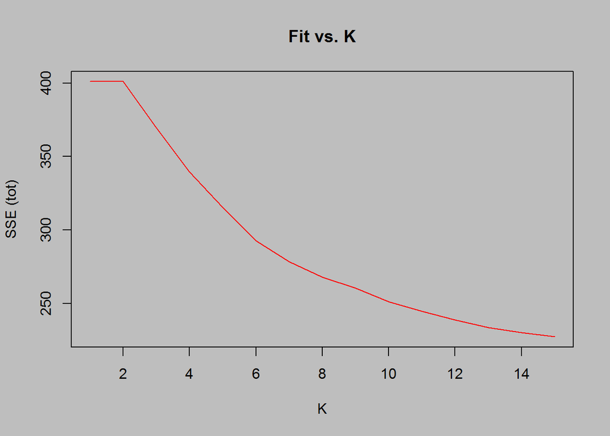

```r
par(bg = "gray")
plot(1:nrow(withoutChatter),withoutChatter[,2],col = "red",main = "Fit vs. K",type = "l",xlab = "K",ylab = "SSE (tot)")
```

Using the elbow method, there is no clear shift in slope of the line as K increases. This curve looks closer to an exponential decay than an elbow. The elbow method, therefore, is not a good metric of choosing the optimal number of market segments. A heuristic such as CH score could find a better optimal K.

Let’s plot the CH scores of all the models tested.

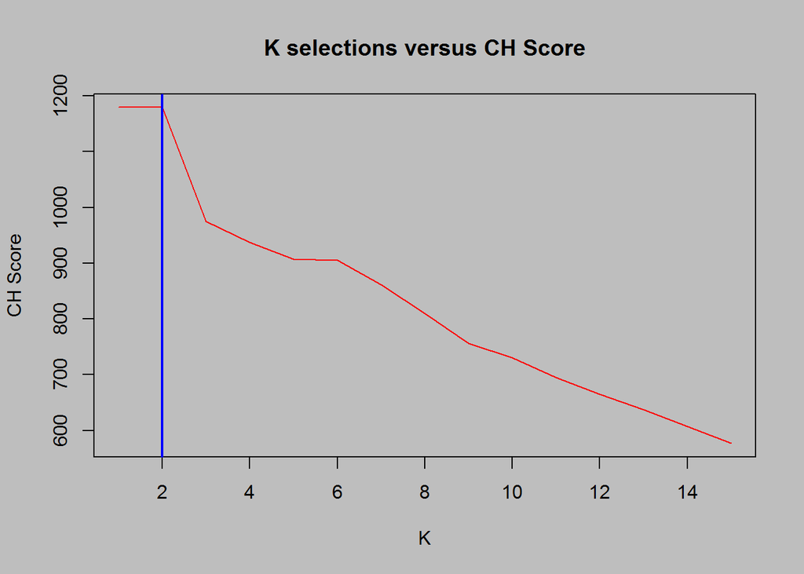

```r
par(bg = "gray")
plot(1:nrow(withoutChatter),withoutChatter[,1],main = "K selections versus CH Score",xlab = "K",ylab = "CH Score",type = "l",col = "red")
abline(v = (which.max(withoutChatter)+1),col = "blue",lw = 2)
```

CH score indicates two optimal market segments. We believe that this is the best metric for determining the clusters because of the fit vs. simplicity trade off inherent within the heuristic and it’s clear answer: two segments.

Next, let’s analyze the important components of that each cluster. In other words, for each cluster’s centriod, let’s look for the centriod with the highest value.

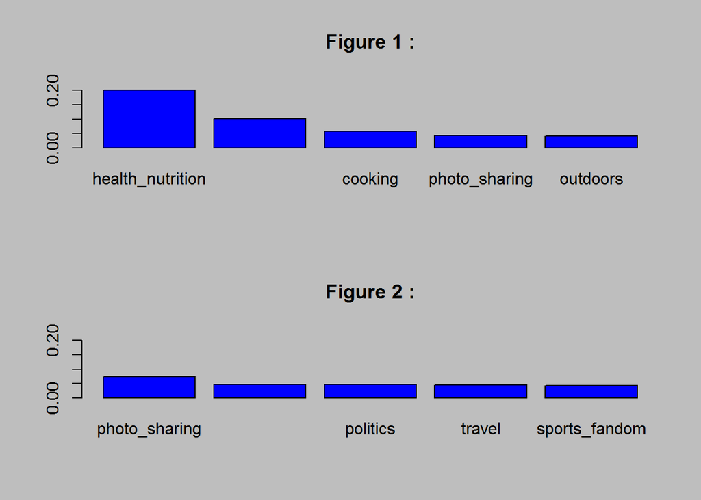

```r
optimalModel = LICORS::kmeanspp(tempDf, (which.max(withoutChatter)+1),nstart = 10)
#plot parameters for each model
topN = 5
centriodMat = matrix(NA,2,topN)
par(bg = "gray",mfrow = c(2,1))
for (k in 1:2)
{
  sorted = sort(optimalModel$centers[k,],decreasing = TRUE)[1:topN]
  barplot(sorted,ylim = c(0,.23),col = "blue",main = paste("Figure",k,":"))
  centriodMat[k,] = names(sorted)
}
```

```r
print(paste("Top",topN,"important centriod indicators per cluster: "))
```

```
## [1] "Top 5 important centriod indicators per cluster: "
```

```r
print(centriodMat)
```

```
##      [,1]               [,2]               [,3]       [,4]
## [1,] "health_nutrition" "personal_fitness" "cooking"  "photo_sharing"
## [2,] "photo_sharing"    "current_events"   "politics" "travel"
##      [,5]
## [1,] "outdoors"
## [2,] "sports_fandom"
```

The one of the clusters looks to be composed of people who are very concious of their health. They seem to be focused on Personal Fitness and are interested in the outdoors. This indicates a very physically active group of people and would recommend that the marketing message ought to be related to personal health. This cluster contains this fraction of social media users:

```r
length(which(optimalModel$cluster == 1))/length(optimalModel$cluster)
```

```
## [1] 0.2048972
```

This clusters contains this fraction of social media users:

```r
length(which(optimalModel$cluster == 2))/length(optimalModel$cluster)
```

```
## [1] 0.7951028
```